# Chapter 8 Multicollinearity

Tianhai Zu (zuti@mail.uc.edu)

**Acknowledgment**: the materials below are partially based on Montgomery, D. C., Peck, E. A., Vining, G. G., Introduction to Linear Regression Analysis (5th Edition), Wiley Series in Probability and Statistics, 2012. This materials was initilated by Yichen Qin and modified by Tianhai Zu for teaching purpose.

### Example

Let us start with a data set. Suppose we want to predict and model patients’ total body fat percentages using measurements of body fat percentages on triceps, thigh, and mid-arm.

y: total body fat percentages

x1: triceps body fat percentages

x2: thigh body fat percentages

x3: mid-arm body fat percentages

```r
BF <- read.csv("data_BodyFat.csv",h=T)
dim(BF)[1]
```

```
## [1] 20
```

```r
names(BF)
```

```
## [1] "x1" "x2" "x3" "y"
```

```r
head(BF)
```

```
##     x1   x2   x3    y
## 1 19.5 43.1 29.1 11.9
## 2 24.7 49.8 28.2 22.8
## 3 30.7 51.9 37.0 18.7
## 4 29.8 54.3 31.1 20.1
## 5 19.1 42.2 30.9 12.9
## 6 25.6 53.9 23.7 21.7
```

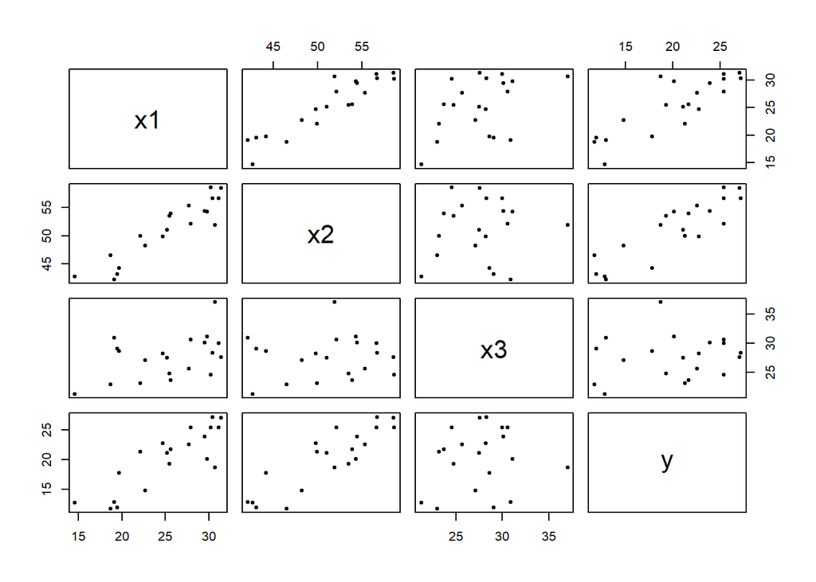

```r
pairs(BF,pch=20)
```

```r
cor(BF)
```

```
##           x1        x2        x3         y
## x1 1.0000000 0.9238425 0.4577772 0.8432654
## x2 0.9238425 1.0000000 0.0846675 0.8780896
## x3 0.4577772 0.0846675 1.0000000 0.1424440
## y  0.8432654 0.8780896 0.1424440 1.0000000
```

```r
model1=lm(y~x1+x2+x3,data=BF)
summary(model1)
```

```
##
## Call:
## lm(formula = y ~ x1 + x2 + x3, data = BF)
##
## Residuals:
##     Min      1Q  Median      3Q     Max
## -3.7263 -1.6111  0.3923  1.4656  4.1277
##
## Coefficients:
##             Estimate Std. Error t value Pr(>|t|)
## (Intercept)  117.085     99.782   1.173    0.258
## x1             4.334      3.016   1.437    0.170
## x2            -2.857      2.582  -1.106    0.285
## x3            -2.186      1.595  -1.370    0.190
##
## Residual standard error: 2.48 on 16 degrees of freedom
## Multiple R-squared:  0.8014, Adjusted R-squared:  0.7641
## F-statistic: 21.52 on 3 and 16 DF,  p-value: 7.343e-06
```

High correlation between triceps and thigh measurements but not with midarm.

### Multicollinearity

- A serious problem that may dramatically impact the usefulness of a regression model is multicollinearity, or near-linear dependence among the regression variables.
- Multicollinearity implies near-linear dependence among the regressors.
- The presence of multicollinearity can dramatically impact the ability to estimate regression coefficients and other uses of the regression model.

Issues with Multicollinearity

- Adding or deleting a predictor variable changes the regression coefficients
- Standard error of the regression coefficients become large when the predictor variables are highly correlated
- (IMPORTANT!!! A large wiggle room in 3D or higher dimension)
- Estimated regression coefficients individually may not be significant but a statistical relationship exists for the set of predictor variables and the response variable

Figure examples:

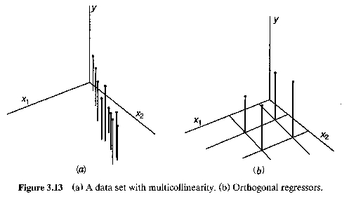

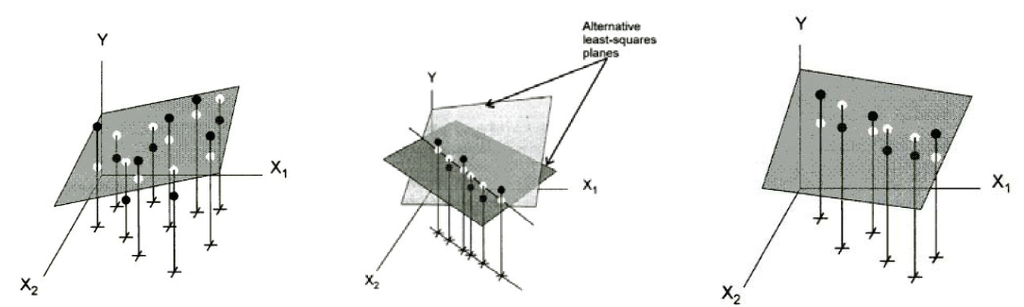

### Informal Diagnostics

- Large changes in the estimated regression coefficients when a predictor variable is added or deleted
- Nonsignificant results in individual tests of regression coefficients for important predictors
- Regression coefficients with a sign that is opposite of that expected
- Large coefficients of simple correlation between pairs of predictor variables
- Wide confidence intervals for the regression coefficients for important predictors

### Variance Inflation Factors

- Variance inflation factors, VIFs, are an important multicollinearity diagnostic. The variance inflation factors can be written as:

$$VIF_j=\frac{1}{1-R^2_j}$$

- where $R^2_j$ is the coefficient of determination obtained from regressing $j$-th covariate, $x_j$, on the other covariates.
- If $x_j$ is highly correlated with any other regressor variables, then $R^2_j$ will be large.
- The square root of the variance inflation factor indicates how much larger the standard error is, compared with what it would be if that variable were uncorrelated with the other predictor variables in the model. For example, if VIF = 10, then $\sqrt{VIF} \approx 3.3$ and the confidence interval is 3.3 times longer than if the regressors had been orthogonal
- Largest VIF used as an indicator of multicollinearity
- Guideline: VIFs > 5 to 10 are considered significant

### Deal with Multicollinearity

Methods for Dealing with Multicollinearity

- Collect more data
- Specify the model differently
- Use Ridge regression

### Ridge Regression

Ridge Regression modifies method of least squares to biased estimators of the regression coefficients

Traditional least square estimation:
$$\hat{\beta} = \arg\min \sum_{i=1}^{n} (y_i - \beta_0 - \sum_{j=1}^{k} \beta_j x_{ij})^2$$

Ridge Regression estimation:
$$\hat{\beta}_\lambda = \arg\min \sum_{i=1}^{n} (y_i - \beta_0 - \sum_{j=1}^{k} \beta_j x_{ij})^2 + \lambda \sum_{j=1}^{p} \beta_j^2$$

Ploting $\lambda$ against the coefficient estimates will show impact of multicollinearity in the stability of the coefficients

Choose $\lambda$ such that $\hat{\beta}_\lambda$ is stable and the MSE is acceptable

Ridge regression is a good alternative if the model user wants to have all regressors in the model

```r
#install.packages("glmnet")
library(glmnet)
library(MASS)
vif <- function(mod, ...) {
    if (any(is.na(coef(mod))))
        stop ("there are aliased coefficients in the model")
    v <- vcov(mod)
    assign <- attr(model.matrix(mod), "assign")
    if (names(coefficients(mod)[1]) == "(Intercept)") {
        v <- v[-1, -1]
        assign <- assign[-1]
    }
    else warning("No intercept: vifs may not be sensible.")
    terms <- labels(terms(mod))
    n.terms <- length(terms)
    if (n.terms < 2) stop("model contains fewer than 2 terms")
    R <- cov2cor(v)
    detR <- det(R)
    result <- matrix(0, n.terms, 3)
    rownames(result) <- terms
    colnames(result) <- c("GVIF", "Df", "GVIF^(1/(2*Df))")
    for (term in 1:n.terms) {
        subs <- which(assign == term)
        result[term, 1] <- det(as.matrix(R[subs, subs])) *
            det(as.matrix(R[-subs, -subs])) / detR
        result[term, 2] <- length(subs)
    }
    if (all(result[, 2] == 1)) result <- result[, 1]
    else result[, 3] <- result[, 1]^(1/(2 * result[, 2]))
    result
}
vif(model1)
```

```
##       x1       x2       x3
## 708.8429 564.3434 104.6060
```

```r
library(glmnet)
rreg=glmnet(x=as.matrix(BF[,-4]), y=BF[,4],alpha=0,lambda = seq(0,0.5,0.01))
rbind(rreg$lambda,rreg$beta)
```

```
## 4 x 51 sparse Matrix of class "dgCMatrix"
```

```
##    [[ suppressing 51 column names 's0', 's1', 's2' ... ]]
```

```
##
##     0.5000000  0.4900000  0.4800000  0.4700000  0.4600000  0.4500000  0.4400000
## x1  0.4312373  0.4316196  0.4322645  0.4330645  0.4339617  0.4349253  0.4359388
## x2  0.4370659  0.4375796  0.4378913  0.4380835  0.4382005  0.4382662  0.4382931
## x3 -0.1141151 -0.1146001 -0.1152155 -0.1159092 -0.1166533 -0.1174327 -0.1182396
##
##     0.4300000  0.4200000  0.4100000  0.4000000  0.3900000  0.3800000  0.3700000
## x1  0.4369938  0.4380862  0.4392147  0.4403794  0.4415814  0.4428224  0.4441045
## x2  0.4382877  0.4382527  0.4381892  0.4380969  0.4379748  0.4378214  0.4376348
## x3 -0.1190699 -0.1199218 -0.1207947 -0.1216887 -0.1226044 -0.1235429 -0.1245053
##
##     0.3600000  0.3500000  0.3400000  0.3300000  0.3200000  0.3100000  0.3000000
## x1  0.4454302  0.4468025  0.4482245  0.4496999  0.4512324  0.4528265  0.4547170
## x2  0.4374127  0.4371527  0.4368520  0.4365074  0.4361157  0.4356731  0.4349902
## x3 -0.1254929 -0.1265073 -0.1275503 -0.1286238 -0.1297298 -0.1308707 -0.1321646
##
##     0.2900000  0.2800000  0.2700000  0.2600000  0.2500000  0.2400000  0.2300000
## x1  0.4566152  0.4585564  0.4605643  0.4626572  0.4651257  0.4676284  0.4704937
## x2  0.4342984  0.4335692  0.4327830  0.4319249  0.4307581  0.4295587  0.4280588
## x3 -0.1334671 -0.1347957 -0.1361629 -0.1375778 -0.1391880 -0.1408211 -0.1426441
##
##     0.2200000  0.2100000  0.2000000  0.1900000  0.1800000  0.1700000  0.1600000
## x1  0.4733934  0.4766835  0.4800450  0.4838628  0.4881014  0.4927671  0.4979024
## x2  0.4265246  0.4246646  0.4227384  0.4204291  0.4177636  0.4147346  0.4113047
## x3 -0.1444910 -0.1465431 -0.1486386 -0.1509747 -0.1535340 -0.1563209 -0.1593584
##
##     0.1500000  0.1400000  0.1300000  0.1200000  0.1100000  0.1000000  0.0900000
## x1  0.5035803  0.5099019  0.5172989  0.5258012  0.5358791  0.5476771  0.5616054
## x2  0.4074109  0.4029663  0.3976080  0.3913056  0.3836600  0.3745417  0.3635975
## x3 -0.1626850 -0.1663544 -0.1705907 -0.1754120 -0.1810646 -0.1876272 -0.1953170
##
##     0.0800000  0.0700000  0.0600000  0.0500000  0.0400000  0.0300000
## x1  0.5792731  0.6012218  0.6302994  0.6697241  0.7271691  0.8186159
## x2  0.3494620  0.3316591  0.3077599  0.2750022  0.2268213  0.1495351
## x3 -0.2049759 -0.2168954 -0.2325715 -0.2537031 -0.2843309 -0.3328752
##
##     0.020000000  0.0100000  .
## x1  0.987221926  1.4028661  4.113612
## x2  0.006197198 -0.3486234 -2.668242
## x3 -0.422073583 -0.6414275 -2.069967
```

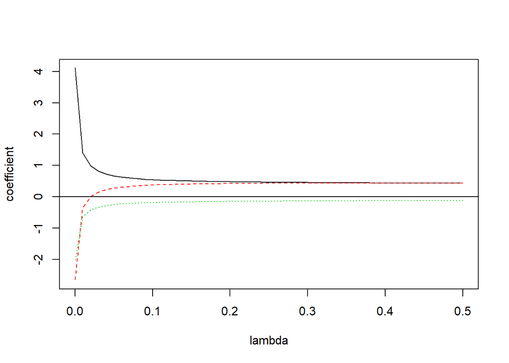

```r
matplot(rreg$lambda,t(rreg$beta),type="l",ylab="coefficient",xlab="lambda")
abline(h=0)
```

### Comments on Ridge Regression

$R^2$ can be defined analogously to least square estimate

Estimates are more stable than least square estimates and less affected by small changes in the data

Estimates provide good estimates of mean responses for levels of the predictor variables outside the region of the observations

Inferential procedures (such as interval estimation) are not applicable since exact distributions are not known

Selection of $\lambda$ is judgmental. In the example above, we still don’t know what lambda we should use. One common way is to use cross valiation and choose the best $\lambda$ that provides minimum MSE:

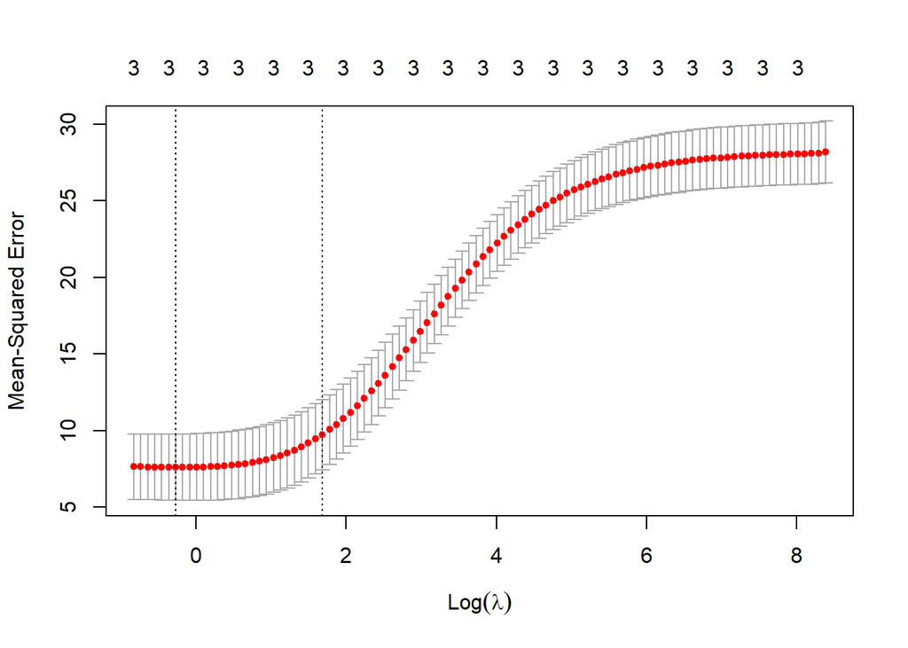

```r
cv_fit <- cv.glmnet(x=as.matrix(BF[,-4]), y=BF[,4],alpha=0,nfolds = 4)
plot(cv_fit)
```

```r
opt_lambda <- cv_fit$lambda.min
opt_lambda
```

```
## [1] 0.7636977
```

We can also predict with ridge regression:

```r
#only matrix form is acceptable in ridge regression
old_x <- as.matrix(BF[,-4])
y_predicted <- predict(rreg, s = opt_lambda, newx = old_x)

newx <- matrix(c(x1=20,x2=40,x3=20),ncol=3)
predict(rreg, s = opt_lambda, newx = newx)
```

```
##             1
## [1,] 13.89482
```

And the R-square:

```r
sst <- sum((BF[,4] - mean(BF[,4]))^2)
sse <- sum((y_predicted - BF[,4])^2)
rsq <- 1 - sse / sst
rsq
```

```
## [1] 0.7783913
```

### Another Example you can try

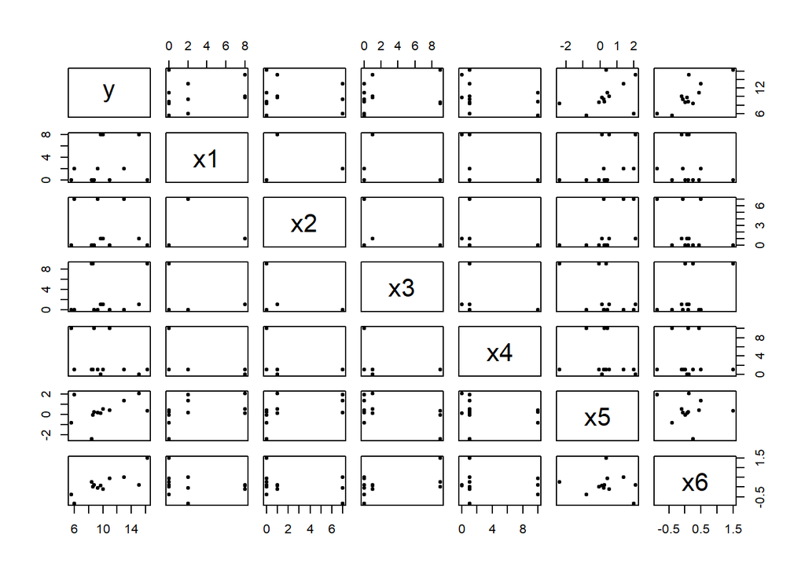

```r
#Webster data
#install.packages("car")
#library(car)
W <- read.csv("data_Webster.csv",h=T)
pairs(W,pch=20)
```

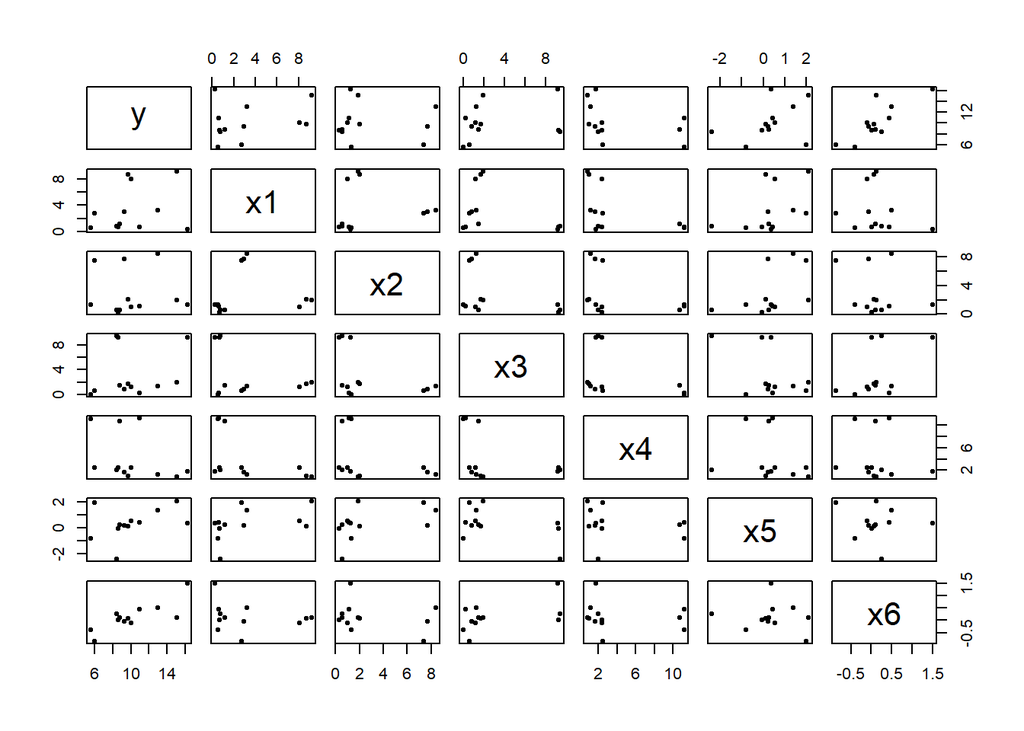

```r
n=dim(W)[1]
pairs(W+cbind(0,matrix(1.5*runif(n*4),n,4),0,0),pch=20)
```

```r
model1=lm(y~x1+x2+x3+x4+x5+x6,data=W)
summary(model1)
```

```
##
## Call:
## lm(formula = y ~ x1 + x2 + x3 + x4 + x5 + x6, data = W)
##
## Residuals:
##          1          2          3          4          5          6          7
## -3.698e-15 -1.545e+00  1.545e+00  7.649e-01 -2.517e-01 -5.132e-01 -6.030e-01
##          8          9         10         11         12
##  4.730e-01  1.300e-01  1.510e-01 -2.371e-01  8.610e-02
##
## Coefficients:
##             Estimate Std. Error t value Pr(>|t|)
## (Intercept)  16.6599    14.0465   1.186 0.288885
## x1           -0.5313     1.3418  -0.396 0.708482
## x2           -0.8385     1.4206  -0.590 0.580722
## x3           -0.7753     1.4094  -0.550 0.605914
## x4           -0.8440     1.4031  -0.601 0.573745
## x5            1.0232     0.3909   2.617 0.047247 *
## x6            5.0470     0.7277   6.936 0.000956 ***
## ---
## Signif. codes:  0 '***' 0.001 '**' 0.01 '*' 0.05 '.' 0.1 ' ' 1
##
## Residual standard error: 1.129 on 5 degrees of freedom
## Multiple R-squared:  0.9457, Adjusted R-squared:  0.8806
## F-statistic: 14.52 on 6 and 5 DF,  p-value: 0.004993
```

```r
rreg <- glmnet(as.matrix(W[,-1]),W[,1],alpha=0,lambda=seq(0,0.2,.01))
rbind(rreg$lambda,rreg$beta)
```

```
## 7 x 21 sparse Matrix of class "dgCMatrix"
```

```
##    [[ suppressing 21 column names 's0', 's1', 's2' ... ]]
```

```
##
##     0.200000000  0.19000000  0.18000000  0.17000000  0.16000000  0.15000000
## x1  0.171841980  0.17147381  0.17141456  0.17135186  0.17109254  0.17083233
## x2 -0.082476146 -0.08346788 -0.08412549 -0.08478592 -0.08565685 -0.08652962
## x3 -0.009277846 -0.01080200 -0.01205498 -0.01334375 -0.01485757 -0.01638751
## x4 -0.097257945 -0.09808449 -0.09862875 -0.09918995 -0.09995534 -0.10072965
## x5  1.001994679  1.00454668  1.00701669  1.00945447  1.01188741  1.01431184
## x6  4.689062458  4.70627701  4.72374209  4.74140345  4.75922489  4.77719648
##
##     0.14000000  0.13000000  0.12000000  0.11000000  0.10000000  0.09000000
## x1  0.17053514  0.17017082  0.16971425  0.16891288  0.16755448  0.16614853
## x2 -0.08744168 -0.08842518 -0.08950679 -0.09095557 -0.09299885 -0.09509029
## x3 -0.01798007 -0.01966612 -0.02147204 -0.02365695 -0.02642894 -0.02928527
## x4 -0.10155258 -0.10245452 -0.10346147 -0.10482746 -0.10676485 -0.10877334
## x5  1.01671515  1.01909850  1.02146117  1.02381419  1.02617989  1.02849637
## x6  4.79534417  4.81366687  4.83216556  4.85082235  4.86959199  4.88857033
##
##     0.08000000  0.07000000  0.06000000  0.05000000  0.04000000  0.03000000
## x1  0.16384486  0.16116009  0.15711833  0.15157243  0.14295745  0.12892511
## x2 -0.09813670 -0.10158390 -0.10647031 -0.11294738 -0.12267351 -0.13813117
## x3 -0.03308809 -0.03732844 -0.04300549 -0.05029319 -0.06082395 -0.07707419
## x4 -0.11170891 -0.11506473 -0.11983615 -0.12619561 -0.13576981 -0.15102595
## x5  1.03081248  1.03306319  1.03527721  1.03740169  1.03940733  1.04118335
## x6  4.90765970  4.92696009  4.94637967  4.96596429  4.98563943  5.00535961
##
##     0.0200000  0.01000000  .
## x1  0.1021866  0.03485326 -0.4249941
## x2 -0.1670323 -0.23888023 -0.7259783
## x3 -0.1066999 -0.17901478 -0.6638667
## x4 -0.1795933 -0.25068390 -0.7328694
## x5  1.0424608  1.04216009  1.0267822
## x6  5.0249027  5.04346264  5.0507129
```

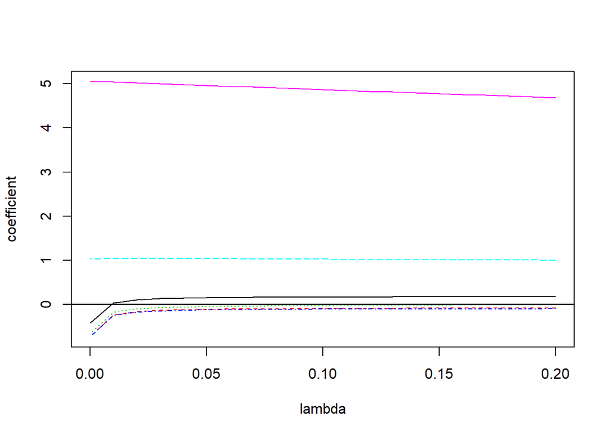

```r
matplot(rreg$lambda,t(rreg$beta),type="l",ylab="coefficient",xlab="lambda")
abline(h=0)
```

```r
#then your turn
```